# Data Text Mining - The Final Project (R Coding)

Adam Kelly

April 19, 2020

For the final project, I have chosen to use my own dataset that I have created by recording 10 separate variables from my customers at my job as a food delivery driver. The goal of this project, through utilization of many techniques I have learned in this class and more specifically usage of map visualizations from lesson 3 and linear modelling from lesson 6, is to statistically analyze my data and visualize meaningful correlations and conclusions between separate variables.

The following data is of delivery orders consisting of 520 separate observations on the following variables: Date, Address, Order Amount, Tip Amount, Age, Time, Tender (Cash/Credit Card/Uber), Tip Included (Y/N) and whether or not a dog was present (Y/N).

The first thing I must do before creating any visualizations or conducting any meaningful analysis is to clean up the data. First I remove any observations containing any NA values, then also remove any observations where the tip amount equals zero. From my experience, a tip of zero is almost always because of a customer forgetting or from a technology/communication error so to get a more accurate representation, I will be omitting 19 rows from the dataset.

```r
df = na.omit(df)
df = subset(df, df$TipAmt != 0)
```

Something else I will do in this preparation phase is to convert applicable columns to their appropriate datatypes so I can run R code as well as create a new column called “TipPercentage” which is the quotient obtained from the tip amount divided by the order amount in order to effectively normalize the numbers.

```r
df$Address = as.character(df$Address)
df$Gender = as.factor(df$Gender)
df$Week = as.numeric(df$Week)
df$TipPercentage = df$TipAmt/df$OrderAmt
df$Age = as.numeric(df$Age)

df$Tender <- revalue(df$Tender, c(C = "CC", cc = "CC",
    "uber" == "Uber"))
```

Lastly I will be omitting any outliers present in the “TipPercentage” column as customers rarely tip much more or much less percentage wise most likely because of an external reason and I do not believe these observations are appropriate for how much they would influence any results.

```r
outliers = boxplot(df$TipPercentage, plot = FALSE)$out
df = df[!df$TipPercentage %in% outliers, ]
```

Now that preparation is done, we are left with 489 observations of clean, workable data.

One of the original inspirations for why I started to collect and record data was because of the mapping tools acquired from lesson 3, so my first visualization will be a map that plots the individual address of each delivery.

The first step in this is to register a Google key to gain access to Google’s API for mapping purposes, as well as use the geocode function to assign each address to its corresponding latitude and longitude coordinates.

```r
register_google(key = "AIzaSyDLHeQB3O4nhAMtQJLRVKpGohvk5FPB3dg")
df$latlon = geocode(df$Address)
```

Next we get a map of Tampa Florida (centered on where the restaurant is located) to use as a basis for plotting the addresses. We are then able to plot each address accordingly and successfully create the first visualization showing the location of each delivery.

[figure not shown]

```r
tampa.map <- get_map(c(-82.49261, 27.91484), zoom = 12,
    maptype = "terrain")

mapSimple <- ggmap(tampa.map)

latlon2 = geocode("1155 S Dale Mabry Hwy, Tampa")

lat = -82.49261
lon = 27.91484

mapSimple + geom_point(data = df, aes(x = df$latlon$lon,
    y = df$latlon$lat), size = 4, alpha = 5/10, color = "blue") +
    ggtitle("Delivery Map - Tampa, Florida") + geom_point(aes(x = latlon2$lon,
    y = latlon2$lat), color = "darkred", size = 6)
```

Now that we have a preliminary map created, we can filter it through different variables to see more details. First I colored each point by tip percentage to visualize which areas may tend to tip more or less alongside a density plot and then combined the two to try and visualize whether or not how dense a neighborhood is has anything to do with its average tip percentage.

[figure not shown]

```r
mapSimple + geom_point(data = df, aes(x = latlon$lon,
    y = latlon$lat, color = TipPercentage), size = 6,
    alpha = 7/10) + ggtitle("Delivery Map - Tampa, Florida") +
    scale_color_gradient(low = "blue", high = "red",
        limits = c(0, 0.3001)) + geom_point(aes(x = latlon2$lon,
    y = latlon2$lat), color = "darkred", size = 6) +
    theme(text = element_text(size = 16), axis.text.x = element_text(angle = 45,
        hjust = 1))
```

[figure not shown]

```r
mapSimple + stat_density2d(aes(x = latlon$lon, y = latlon$lat,
    fill = ..level.., alpha = 0.25), size = 0.01, bins = 30,
    data = df, geom = "polygon") + geom_point(data = df,
    aes(x = latlon$lon, y = latlon$lat, color = TipPercentage),
    size = 6, alpha = 1/10) + geom_point(aes(x = latlon2$lon,
    y = latlon2$lat), color = "darkred", size = 6) +
    ggtitle("Delivery Map - Tampa Florida") + theme(text = element_text(size = 16),
    axis.text.x = element_text(angle = 45, hjust = 1))
```

[figure not shown]

```r
mapSimple + geom_point(data = df, aes(x = latlon$lon,
    y = latlon$lat, color = TipPercentage), size = 6,
    alpha = 7/10) + ggtitle("Delivery Map - Tampa, Florida") +
    scale_color_gradient(low = "blue", high = "red",
        limits = c(0, 0.3001)) + geom_point(aes(x = latlon2$lon,
    y = latlon2$lat), color = "darkred", size = 6) +
    stat_density2d(aes(x = latlon$lon, y = latlon$lat,
        fill = ..level..), size = 0.01, bins = 30,
        alpha = 0.7, data = df) + theme(text = element_text(size = 16),
    axis.text.x = element_text(angle = 45, hjust = 1))
```

Another demonstration of map visualizations shows density among female compared to male customers as well as dog owners compared to non-dog owners.

[figure not shown]

```r
p1 = mapSimple + geom_point(data = subset(df, Gender ==
    "Female"), aes(x = latlon$lon, y = latlon$lat,
    color = Age), size = 6, alpha = 7/10) + scale_color_gradient(low = "blue",
    high = "red") + geom_point(aes(x = latlon2$lon,
    y = latlon2$lat), color = "darkred", size = 6) +
    stat_density2d(aes(x = latlon$lon, y = latlon$lat),
        size = 0.01, bins = 30, alpha = 0.75, data = subset(df,
            Gender == "Female")) + ggtitle("Female Customers") +
    theme(text = element_text(size = 16), axis.text.x = element_text(angle = 45,
        hjust = 1))

p2 = mapSimple + geom_point(data = subset(df, Gender ==
    "Male"), aes(x = latlon$lon, y = latlon$lat, color = Age),
    size = 6, alpha = 7/10) + scale_color_gradient(low = "blue",
    high = "red") + geom_point(aes(x = latlon2$lon,
    y = latlon2$lat), color = "darkred", size = 6) +
    stat_density2d(aes(x = latlon$lon, y = latlon$lat),
        size = 0.01, bins = 30, alpha = 0.75, data = subset(df,
            Gender == "Male")) + ggtitle("Male Customers") +
    theme(text = element_text(size = 16), axis.text.x = element_text(angle = 45,
        hjust = 1))

p3 = mapSimple + geom_point(data = subset(df, Dog ==
    "Yes"), aes(x = latlon$lon, y = latlon$lat, color = TipPercentage),
    size = 6, alpha = 7/10) + scale_color_gradient(low = "blue",
    high = "red", limits = c(0, 0.3001)) + geom_point(aes(x = latlon2$lon,
    y = latlon2$lat), color = "darkred", size = 6) +
    stat_density2d(aes(x = latlon$lon, y = latlon$lat),
        size = 0.01, bins = 30, alpha = 0.75, data = subset(df,
            Gender == "Female")) + ggtitle("Dog Present") +
    theme(text = element_text(size = 16), axis.text.x = element_text(angle = 45,
        hjust = 1))

p4 = mapSimple + geom_point(data = subset(df, Dog ==
    "No"), aes(x = latlon$lon, y = latlon$lat, color = TipPercentage),
    size = 6, alpha = 7/10) + scale_color_gradient(low = "blue",
    high = "red", limits = c(0, 0.3001)) + geom_point(aes(x = latlon2$lon,
    y = latlon2$lat), color = "darkred", size = 6) +
    stat_density2d(aes(x = latlon$lon, y = latlon$lat),
        size = 0.01, bins = 30, alpha = 0.75, data = subset(df,
            Gender == "Female")) + ggtitle("No Dog Present") +
    theme(text = element_text(size = 16), axis.text.x = element_text(angle = 45,
        hjust = 1))


grid.arrange(p1, p2, ncol = 2)
```

Something particularly interesting we can observe from these graphs is that out of 229 females and 260 males, it appears that females tend to stay closer to the restaurant and are more clustered compared to males whom are more spread out.

[figure not shown]

```r
grid.arrange(p3, p4, ncol = 2)
```

We can also see from these visualizations that there appears to be more non-dog owners (309) compared to dog owners (180) and there is a significant disparity East towards Downtown Tampa.

The last map visualization I will create is a series of visualizations plotting the orders within each hour. My work shifts are always between the hours of 4-10 so I have plotted the number of orders received accordingly by converting the time variable to a date time object as well as subsetting the data by each hour.

[figure not shown]

```r
df$Time = as.POSIXct(df$Time, format = "%H:%M:%S")

time45 = with(df, df[hour(Time) >= 4 & hour(Time) <
    5, ])
time56 = with(df, df[hour(Time) >= 5 & hour(Time) <
    6, ])
time67 = with(df, df[hour(Time) >= 6 & hour(Time) <
    7, ])
time78 = with(df, df[hour(Time) >= 7 & hour(Time) <
    8, ])
time89 = with(df, df[hour(Time) >= 8 & hour(Time) <
    9, ])
time910 = with(df, df[hour(Time) >= 9 & hour(Time) <
    10, ])

p1 = mapSimple + geom_point(data = time45, aes(x = latlon$lon,
    y = latlon$lat, color = TipPercentage), size = 6,
    alpha = 7/10) + scale_color_gradient(low = "blue",
    high = "red") + geom_point(aes(x = latlon2$lon,
    y = latlon2$lat), color = "darkred", size = 6) +
    ggtitle("4 PM - 5 PM") + theme(text = element_text(size = 16),
    axis.text.x = element_text(angle = 45, hjust = 1))

p2 = mapSimple + geom_point(data = time56, aes(x = latlon$lon,
    y = latlon$lat, color = TipPercentage), size = 6,
    alpha = 7/10) + scale_color_gradient(low = "blue",
    high = "red") + geom_point(aes(x = latlon2$lon,
    y = latlon2$lat), color = "darkred", size = 6) +
    ggtitle("5 PM - 6 PM") + theme(text = element_text(size = 16),
    axis.text.x = element_text(angle = 45, hjust = 1))

p3 = mapSimple + geom_point(data = time67, aes(x = latlon$lon,
    y = latlon$lat, color = TipPercentage), size = 6,
    alpha = 7/10) + scale_color_gradient(low = "blue",
    high = "red") + geom_point(aes(x = latlon2$lon,
    y = latlon2$lat), color = "darkred", size = 6) +
    ggtitle("6 PM - 7 PM") + theme(text = element_text(size = 16),
    axis.text.x = element_text(angle = 45, hjust = 1))

p4 = mapSimple + geom_point(data = time78, aes(x = latlon$lon,
    y = latlon$lat, color = TipPercentage), size = 6,
    alpha = 7/10) + scale_color_gradient(low = "blue",
    high = "red") + geom_point(aes(x = latlon2$lon,
    y = latlon2$lat), color = "darkred", size = 6) +
    ggtitle("7 PM - 8 PM") + theme(text = element_text(size = 16),
    axis.text.x = element_text(angle = 45, hjust = 1))

p5 = mapSimple + geom_point(data = time89, aes(x = latlon$lon,
    y = latlon$lat, color = TipPercentage), size = 6,
    alpha = 7/10) + scale_color_gradient(low = "blue",
    high = "red") + geom_point(aes(x = latlon2$lon,
    y = latlon2$lat), color = "darkred", size = 6) +
    ggtitle("8 PM - 9 PM") + theme(text = element_text(size = 16),
    axis.text.x = element_text(angle = 45, hjust = 1))

p6 = mapSimple + geom_point(data = time910, aes(x = latlon$lon,
    y = latlon$lat, color = TipPercentage), size = 6,
    alpha = 7/10) + scale_color_gradient(low = "blue",
    high = "red") + geom_point(aes(x = latlon2$lon,
    y = latlon2$lat), color = "darkred", size = 6) +
    ggtitle("9 PM - 10 PM") + theme(text = element_text(size = 16),
    axis.text.x = element_text(angle = 45, hjust = 1))

grid.arrange(p1, p2, ncol = 2)
```

[figure not shown]

```r
grid.arrange(p3, p4, ncol = 2)
```

[figure not shown]

```r
grid.arrange(p5, p6, ncol = 2)
```

From this we can see that, as one would expect, the day starts slow and peaks between 6-8 PM and then begins to slow down again.

Next I will be utilizing skills acquired from lesson 6 to conduct and visualize linear modeling and predictive analysis.

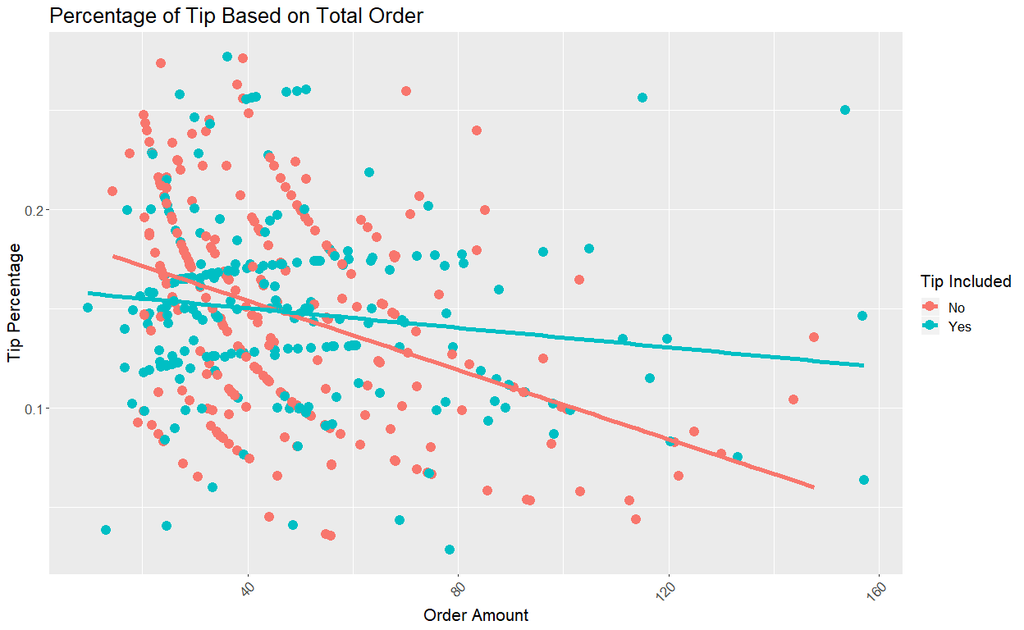

```r
df = subset(df, df$OrderAmt <= 160)
gratyes = subset(df, df$GratIncl == "Yes")
gratno = subset(df, df$GratIncl == "No")
df$Date = as.Date(df$Date)

ggplot(df, aes(df$OrderAmt, df$TipPercentage, color = df$GratIncl)) +
    geom_jitter(size = 4) + xlab("Order Amount") +
    ylab("Tip Percentage") + labs(color = "Tip Included") +
    ggtitle("Percentage of Tip Based on Total Order") +
    geom_smooth(method = "lm", se = FALSE, size = 2) +
    theme(text = element_text(size = 16), axis.text.x = element_text(angle = 45,
        hjust = 1))
```

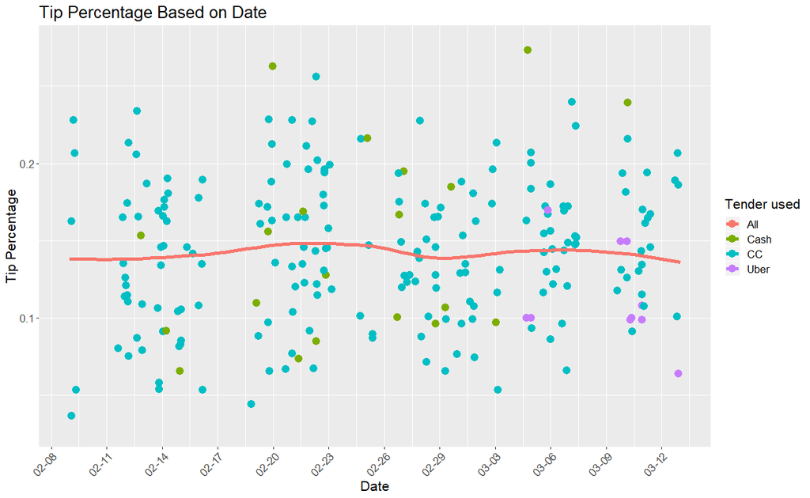

```r
ggplot(df, aes(df$Date, df$TipPercentage, color = df$Tender)) +
    geom_jitter(size = 4) + xlab("Date") + ylab("Tip Percentage") +
    labs(color = "Tender used") + ggtitle("Tip Percentage Based on Date") +
    scale_x_date(breaks = "3 days", date_labels = "%m-%d",
        limits = as.Date(c("2020-02-09", "2020-03-13"))) +
    geom_smooth(aes(group = 1, col = "All"), se = FALSE,
        size = 2) + theme(text = element_text(size = 16),
    axis.text.x = element_text(angle = 45, hjust = 1))
```

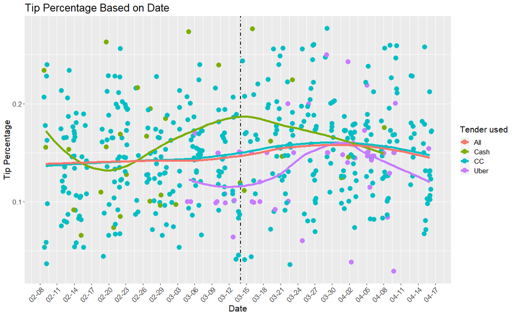

```r
ggplot(df, aes(df$Date, df$TipPercentage, color = df$Tender)) +
    geom_vline(xintercept = as.numeric(df$Date[239]),
        size = 1, linetype = 4) + geom_jitter(size = 4) +
    xlab("Date") + ylab("Tip Percentage") + labs(color = "Tender used") +
    ggtitle("Tip Percentage Based on Date") + geom_smooth(se = FALSE,
    size = 2) + scale_x_date(breaks = "3 days", date_labels = "%m-%d") +
    geom_smooth(aes(group = 1, col = "All"), se = FALSE,
        size = 2) + theme(text = element_text(size = 16),
    axis.text.x = element_text(angle = 45, hjust = 1))
```

For these next graphs, the graph on top shows tipping trends among the three types of tenders used: credit card, cash, or Uber orders up until President Trump entered the country into a national state of emergency (March 13). The graph on bottom shows the overall pattern from when I first started recording data (February 9) up until April 17. The second graph shows a significant rise in the average tip percentage during initial coronavirus outbreak and then starts to decline back to normal in the following weeks. While I did not start recording Uber delivery data until early March, we can also see that the average tip amount rose drastically during the couple of weeks following the outbreak and then began to drop just as much. I initially thought that the pandemic would discourage higher tips on account of the loss of jobs/income, however it seems that people grew more empathetic towards “essential workers” such as myself and were more generous with tips and then sort of lost that empathy and began to tip more normal amounts. The overall average tip percentage prior to the outbreak was 14.17 percent and after the outbreak it has been 15.4 which is a significant increase that, when taking into account the average order cost (47.43), equates to an extra 58 cents per order.

However if we look at the average order amount before the outbreak (49.53) and after the outbreak (45.34), we can calculate that there is only an absolute difference of 3 cents, meaning the overall tip amount per order has not changed - rather it seems that people have been ordering less food but are tipping more during the coronavirus pandemic which makes sense considering the guidelines surrounding self-isolation. Something else worth noting is that the amount of cash orders has drastically gone down to the point where I had not received a single one past April 8th. This is almost definitely because people do not want to physically handle cash because it could be contaminated.

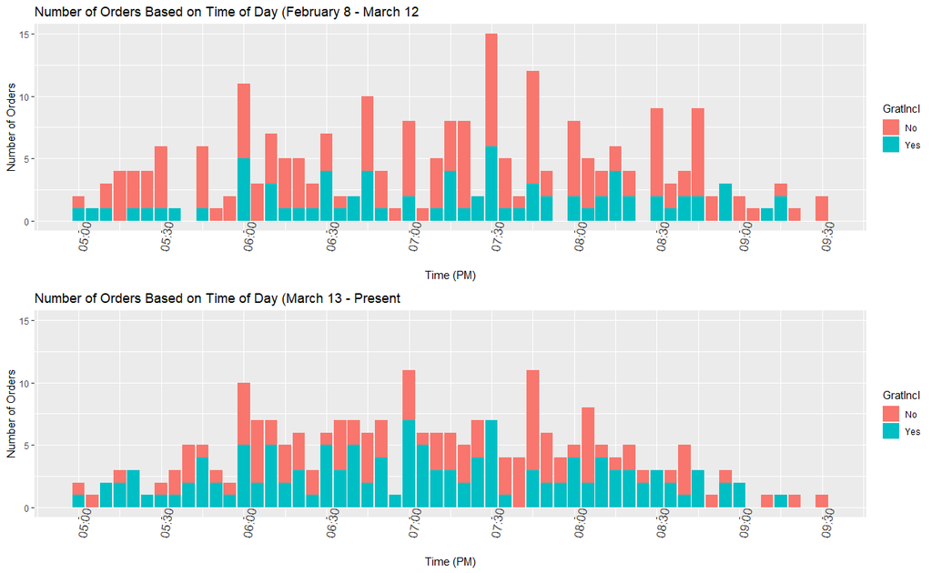

```r
df2 = df[238:nrow(df), ]
df2 = with(df[238:nrow(df), ], df[238:nrow(df), ][hour(Time) >=
    5, ])
# time56 = with(df, df[hour(Time) >= 5 & hour(Time)
# < 6,])

p1 = ggplot(with(df[1:238, ], df[1:238, ][hour(Time) >=
    5, ]), aes(x = Time, fill = GratIncl)) + geom_bar() +
    theme(axis.text.x = element_text(size = 12, angle = 80)) +
    scale_x_datetime(date_breaks = "30 min", date_labels = "%H:%M") +
    ylab("Number of Orders") + ggtitle("Number of Orders Based on Time of Day (February 8 - March 12") +
    xlab("Time (PM)") + ylim(0, 15)

p2 = ggplot(df2, aes(x = Time, fill = GratIncl)) +
    geom_bar() + theme(axis.text.x = element_text(size = 12,
    angle = 80)) + scale_x_datetime(date_breaks = "30 min",
    date_labels = "%H:%M") + ylab("Number of Orders") +
    ggtitle("Number of Orders Based on Time of Day (March 13 - Present") +
    xlab("Time (PM)") + ylim(0, 15)

grid.arrange(p1, p2, nrow = 2)
```

In this last visualization we can see the times in which customers had their food delivered. The first graph shows times up until the entrance to the national state of emergency while the lower graph shows the time from then to the present. We can see that before March 13, customers were hardly any more likely to order food at any given time, however there are peaks during the normal dinner hours spread throughout 6-8 PM. After March 13 however, we can observe that order times followed a more normally distributed sort of bell curve and busy times were much more distinguishable. This, in my opinion, is likely because people led more structured lives on account of not being able to go to work, go to restaurants, events, etc., and thus they were able to order more during more spread out times rather than selective integers. What I mean by this is instead of a large population of customers say getting off of work at 6 and coming home to order food at 6:30, they instead ordered off of a more continuous scale because there were no time structured events (such as getting off at work or picking up a child from a lesson) in place.

## Reflections

Overall I am very satisfied with how this analysis turned out. The goal of this project was to utilize skills acquired from this class to effectively take a dataset and visualize it. While there is certainly much more analysis that can be done with the multitude of variables and statistical tests such as t-tests, hypothesis tests, ANOVA, etc., I am proud of the work I have done and felt like I accomplished my goal of analyzing data that I created myself and creating useful visualizations and conclusions and becoming much more proficient at R along the way. I am eager to continue analysis on my future delivery data and progress as a data scientist.